# R Notebook

```r
library(tidyverse)
library(cluster)
library(factoextra)
library(dendextend)
library(broom)
```

| CustomerID | Gender | Age | Annual Income (k$) | Spending Score (1-100) |
| --- | --- | --- | --- | --- |
| 1 | Male | 19 | 15 | 39 |
| 2 | Male | 21 | 15 | 81 |
| 3 | Female | 20 | 16 | 6 |
| 4 | Female | 23 | 16 | 77 |
| 5 | Female | 31 | 17 | 40 |
| 6 | Female | 22 | 17 | 76 |
| 7 | Female | 35 | 18 | 6 |
| 8 | Female | 23 | 18 | 94 |
| 9 | Male | 64 | 19 | 3 |
| 10 | Female | 30 | 19 | 72 |

[output cut: 190 more lines]

Task 1

Do some exploratory analysis on the data. Comment on findings.

```r
mall %>%
  skimr::skim()
```

```
── Data Summary ────────────────────────
                           Values
Name                       Piped data
Number of rows             200
Number of columns          5
_______________________
Column type frequency:
  character                1
  numeric                  4
________________________
Group variables            None
```

|  | skim_variable | n_missing | complete_rate | min | max | empty | n_unique | whitespace |
| --- | --- | --- | --- | --- | --- | --- | --- | --- |
| 1 | Gender | 0 | 1 | 4 | 6 | 0 | 2 | 0 |

|  | skim_variable | n_missing | complete_rate | mean | sd | p0 | p25 | p50 | p75 | p100 | hist |
| --- | --- | --- | --- | --- | --- | --- | --- | --- | --- | --- | --- |
| 1 | CustomerID | 0 | 1 | 100.50 | 57.87918 | 1 | 50.75 | 100.5 | 150.25 | 200 | ▇▇▇▇▇ |
| 2 | Age | 0 | 1 | 38.85 | 13.96901 | 18 | 28.75 | 36.0 | 49.00 | 70 | ▆▇▅▃▂ |
| 3 | Annual Income (k$) | 0 | 1 | 60.56 | 26.26472 | 15 | 41.50 | 61.5 | 78.00 | 137 | ▆▇▇▂▁ |
| 4 | Spending Score (1-100) | 0 | 1 | 50.20 | 25.82352 | 1 | 34.75 | 50.0 | 73.00 | 99 | ▃▃▇▃▃ |

Data is well distributed Each row is a Customer which age, gender with there income and income score

Task 2

We are interested in creating a marketing campaign to target customers based on their spending score and annual income. Select an appropriate value for k and perform k-means clustering to find if there are meaningful clusters in the data to target the customers.

```r
mall_scale <-
mall %>%
  select(`Annual Income (k$)`, `Spending Score (1-100)`) %>%
  mutate(across(where(is.numeric), scale))
```

```r
max_k <- 25

mall_clusters <- tibble(k = 1:max_k) %>%
  mutate(kclust = map(k, ~ kmeans(mall_scale, .x, nstart = 50)),
         tidied = map(kclust, tidy),
         glanced = map(kclust, glance),
         augmented = map(kclust, augment, mall_scale))
```

```r
mall_clusters_out <- mall_clusters %>%
  unnest(glanced)
```

elbow:

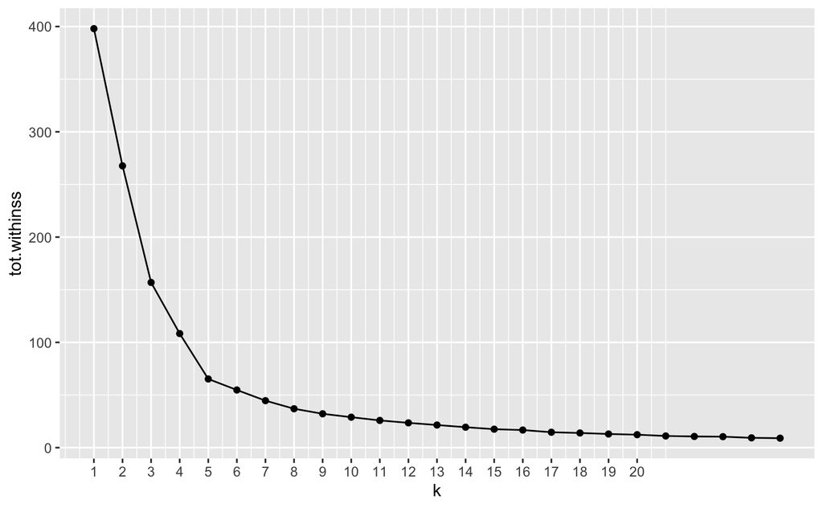

```r
ggplot(mall_clusters_out, aes(x = k, y = tot.withinss)) +
  geom_point() +
  geom_line() +
  scale_x_continuous(breaks = seq(1, 20, by = 1))
```

silhouette

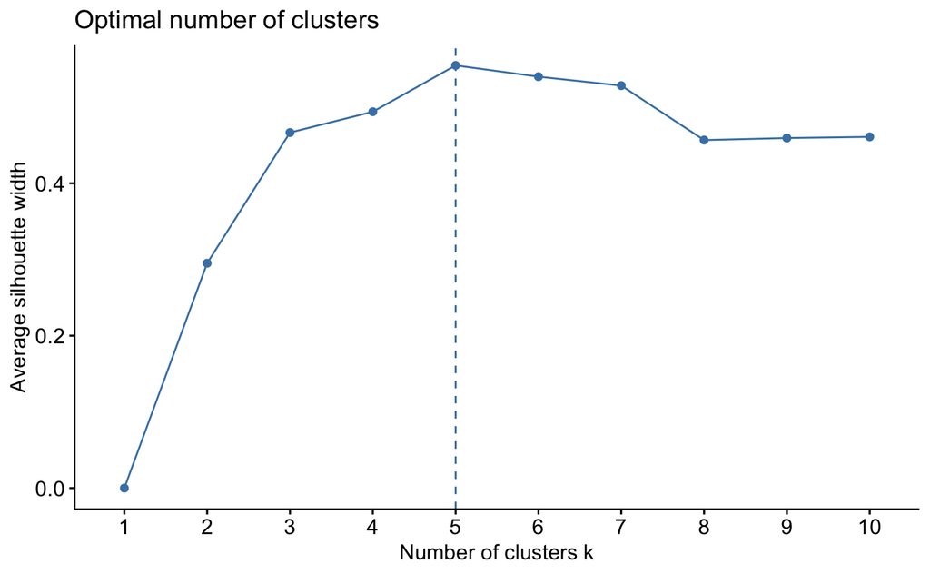

```r
fviz_nbclust(mall_scale,
             kmeans,
             method = "silhouette",
             nstart = 50)
```

```
Clustering k = 1,2,..., K.max (= 10): .. done
Bootstrapping, b = 1,2,..., B (= 100)  [one "." per sample]:
.................................................. 50
.................................................. 100
```

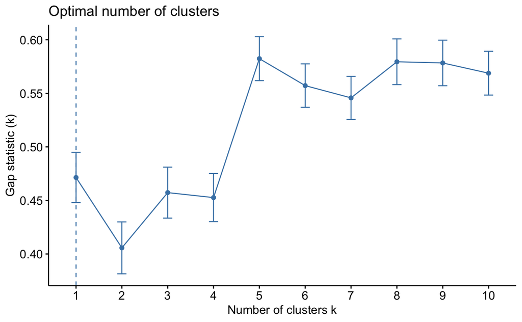

```r
fviz_nbclust(mall_scale,
             kmeans,
             method = "gap_stat",
             nstart = 50,
             k.max = 10)
```

I think 5 clusters

```r
clustered_mall <- kmeans(mall_scale,
                             centers = 5,
                             nstart = 100)
```

| Annual Income (k$) | Spending Score (1-100) | .cluster |
| --- | --- | --- |
| -1.73464625 | -0.433713114 | 3 |
| -1.73464625 | 1.192711064 | 4 |
| -1.69657236 | -1.711617825 | 3 |
| -1.69657236 | 1.037813523 | 4 |
| -1.65849848 | -0.394988729 | 3 |
| -1.65849848 | 0.999089138 | 4 |
| -1.62042459 | -1.711617825 | 3 |
| -1.62042459 | 1.696128071 | 4 |
| -1.58235070 | -1.827790981 | 3 |
| -1.58235070 | 0.844191597 | 4 |

[output cut: 190 more lines]

Task 3

Visualise the clustering for your chosen value of k.

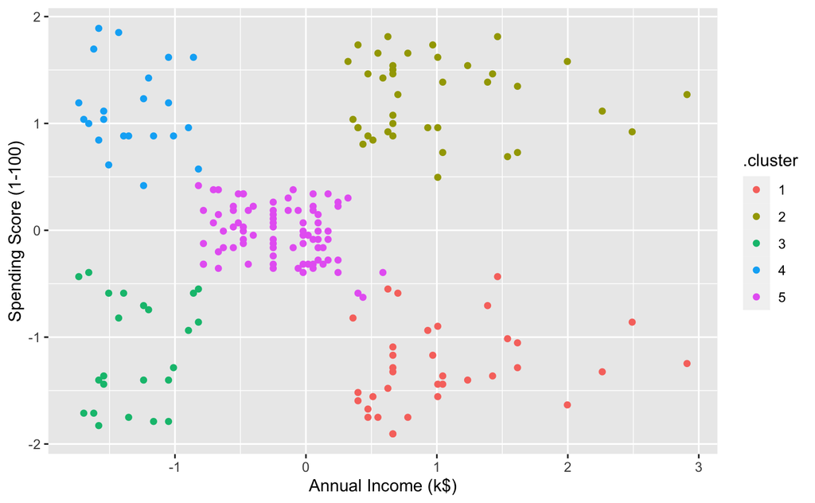

```r
mall_with_clusters %>%
  ggplot(aes(x = `Annual Income (k$)`, y = `Spending Score (1-100)`)) +
    scale_fill_discrete(name ="Type", labels = c("Big money no spend", "Big Money Big Spend", "No Money No spend", "No Money still spend!!", "Average at both")) +
  geom_point(aes(col = .cluster))
```

```r
NA
NA
```

Task 4

Do you think the clustering seems a good fit for this data?

I think it looks pretty good! the groups look how they would if my human eye was to do it!

Task 5

Comment on the attributes of one or two of the clusters (maybe even give them an appropriate label if you like - similar to section 4.1 of the ‘Segmentation & clustering intro’ lesson where we saw labels such as “Super Fans” and “Tag-Alongs”).

```r
fun <-
mall_with_clusters %>%
  mutate(.cluster = case_when(str_detect(
                                         .cluster, "1") ~ "Big money no spend",
                              str_detect(.cluster, "2") ~ "Big Money Big Spend",
                              str_detect(.cluster, "3") ~ "No Money No spend",
                              str_detect(.cluster, "4") ~ "No Money still spend!!",
                              str_detect(.cluster, "5") ~ "Average at both"))
```

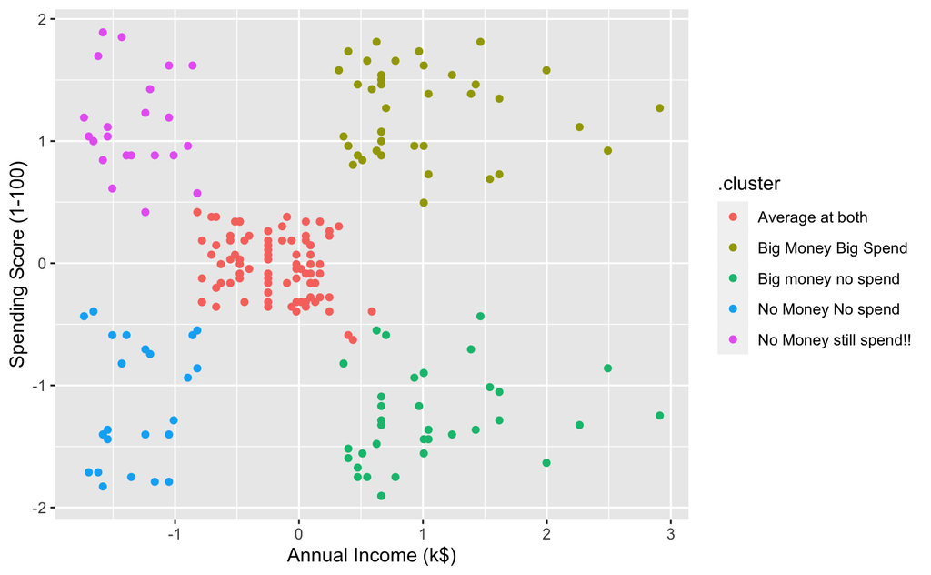

```r
fun %>%
  ggplot(aes(x = `Annual Income (k$)`, y = `Spending Score (1-100)`)) +
  geom_point(aes(col = .cluster))
```